# Einleitung

### Evaluation des CNN

```python
# Vorhersage auf Testdaten mit optimalen Parametern

cnn_grid_pred = grid_result.predict(X_test)
```

```python
# Aufhebung der Normalisierung von Vorhersagewerten und tatsächlichen Kupferpreisen

cnn_grid_pred = cnn_grid_pred.reshape((len(cnn_grid_pred), 1))
cnn_grid_pred_rescaled = scaler_target.inverse_transform(cnn_grid_pred)

cnn_grid_actual = y_test.reshape((len(y_test), 1))
cnn_grid_actual_rescaled = scaler_target.inverse_transform(cnn_grid_actual)
```

```python
# Metriken für Vorhersage auf Testdaten

perf_cnn = determineRegressionMetrics(cnn_grid_actual_rescaled,cnn_grid_pred_rescaled)
```

```
Mean absolute error = 226.28
Mean squared error = 75910.41
Median absolute error = 198.84
R2 score = 0.85
Root Mean Squared Logarithmic Error = 0.04697010522981978
```

**Erkenntnisse**:

Bei der Vorhersage auf den Testdaten liegt der R2-Score des CNN bei 0.85. Damit performt das CNN-Modell deutlich schlechter, als die ARIMAX-Modelle.

Zu beachten gilt jedoch, dass sich mit einer Optimierung von weiteren Hyperparametern, z.B. der Lernrate oder den Optimizern wohl noch einige Prozentpunkte erzielen lassen können. Es erscheint aber unwahrscheinlich, die Ergebnisse der ARIMAX-Modelle zu erzielen.

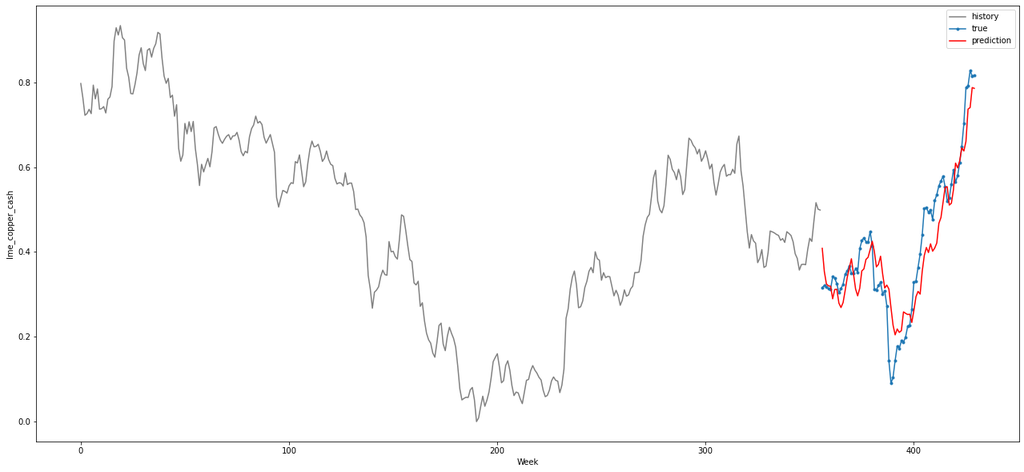

```python
# Visualisieren der  Zeitreihe inkl. Vorhersage
plt.plot(np.arange(0, len(y_train)), y_train, '0.5', label="history")
plt.plot(np.arange(len(y_train), len(y_train) + len(y_test)), y_test, marker='.', label="true")
plt.plot(np.arange(len(y_train), len(y_train) + len(y_test)), cnn_grid_pred, 'r', label="prediction")
plt.ylabel('lme_copper_cash')
plt.xlabel('Week')
plt.legend()
plt.show();
```

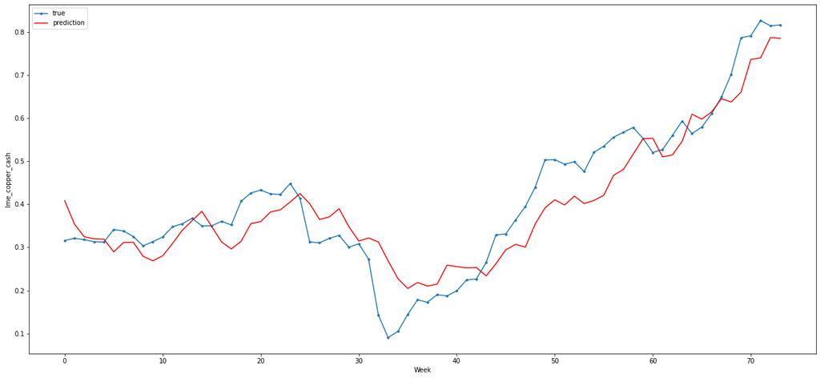

```python
# Visualisierung der Prognosegüte auf den Testdaten
plt.plot(y_test, marker='.', label="true")
plt.plot(cnn_grid_pred, 'r', label="prediction")
plt.ylabel('lme_copper_cash')
plt.xlabel('Week')
plt.legend()
plt.show();
```

**Fazit**:

Die beiden voranstehenden Abbildungen zeigen deutlich auf, dass das CNN-Modell weit weniger gut performt als die ARIMAX-Modelle. Der CNN scheint Probleme zu haben, die sehr volatilen und stark schwankenden Verläufe, die wiederum deutlich von den Trainingsdaten abweichen, abzubilden und prognostiziert Ergebnisse, die "smoother" und auch leicht zeitverzögert erscheinen.

## Gesamtfazit zu den Modellen (ARIMA / CNN)

In den vorangegangenen Kapiteln wurden nun sowohl ein klassisches Time-Series-Modell (ARIMA in unterschiedlichen Ausprägungen) aus dem Machine-Learning Bereich als auch ein Klassiker aus dem Bereich der neuronalen Netze, ein CNN, vorgestellt und auf den Use-Case angewandt.

Anhand einiger Kriterien soll nun ein abschließendes Fazit gezogen werden:

- **Performance der Ergebnisse**: Bei den Ergebnissen ist ein klarer Sieger erkennbar. Konnte bei den univariaten Zeitreihen-Modellen des ARIMA nur das manuell trainierte über einige Wochen überzeugen, performte das ARIMAX - eine Erweiterung des bekannten ARIMA-Modells - durchgehend sehr gut bis exzellent. Hier hatte sich auch die Frage des Overfitting gestellt, da die Prognose nahezu perfekt die tatsächlichen Werte widerspiegelt. Mithilfe einer angepassten 3-fold-cross-validation wurde diese Vermutung auch teilweise bestätigt, dennoch konnte das Modell auch hier überzeugen. Das CNN-Modell blieb mit den inital eingestellten Parametern weit unter dieser Performance und konnte erst mit einem Hyperparametertuning deutlich verbessert werden. Insgesamt bleibt es aber hinter dem ARIMAX-Modell zurück.
- **Geschwindigkeit**: Die Trainingsdauer war sowohl bei den ARIMA-Modellen als auch beim CNN nicht besonders lange. Dennoch benötigt das CNN mehr Zeit, da mehr zu tunende Parameter vorliegen. Dies könnte sich auch noch einmal steigern, sofern noch mehr Hyperparameter in die Grid-Search einfließen sollten.
- **Erklärbarkeit**: Auch hier haben die ARIMA-Modelle die Nase vorne. So lässt sich einem Fachfremden die Materie rund um die ARIMA-Modelle leichter erläutern, als der Aufbau eines neuronalen Netzes, in diesem Fall das CNN.

# Gesamtfazit

Im Rahmen dieser Projektarbeit, die sich über mehrere Jupyter Notebooks, modular aufgebaut, erstreckt, wurden Kupferpreise und Kupferbestände aus dem Datenbestand der London Metal Exchange (Rohstoffbörse in London) analysiert und entsprechende Machine Learning bzw. Deep Learning Modelle zur Prognose des Kupferpreises trainiert, getestet und entsprechend zusammenfassend bewertet.

Der Kern und das wesentliche Ziel dieser Projektarbeit bestand darin, verschiedene Modelle (aus den Bereichen des klassischen Machine Learnings, als auch aus dem Bereich des Deep Learnings, auf den Use-Case, der Prognose des Kupferpreises, anzuwenden und zu testen. Dabei kamen nicht nur klassische Machine Learning Modelle zur Lösung von Zeitreihenproblemen (hier: ARIMA und ARIMAX) zum Einsatz, sondern es wurden ebenso klassische Machine Learning Modelle aus dem Bereich der Regressionsanalyse auf das Zeitreihenproblem angewandt (hier: Random Forest und Gradient Boosting Tree). Aus dem Bereich des Deep Learnings wurde ein CNN und ein LSTM inkl. Hyperparametertuning implementiert und deren Performance auf den Testdaten unserer Zeitreihe evaluiert.

Das Training der Modelle erfolgte konsistent auf 80% der vorliegenden Zeitreihendaten, während die Evaluation der Modelle auf den restlichen/verbleibenden 20% der Zeitreihendaten ausgeführt wurde. Verwendet wurde die Zeitreihe der Kupferpreise und die Zeitreihe der Kupferbestände von 2012 - 2020 auf täglicher Basis. Für die Data Preparation und die Modellierung der Daten wurde der Datensatz mit täglichen Daten auf wöchentliche Daten aggregiert.

Gegenstand der vorliegenden Projektarbeit war also die Prognose der wöchentlichen, durchschnittlichen Kupferpreisentwicklung.

Die Performance der besten Modelle im Überblick:

**1. SARIMAX**

- MAPE: 0.000529
- ME: -0.302370
- MAE: 3.139232
- MPE: -0.000093
- RMSE: 3.868952

**3. Random Forest**

- Mean absolute error = 114.0
- Mean squared error = 29520.16
- Median absolute error = 59.96
- R2 score = 0.93
- Root Mean Squared Logarithmic Error = 0.027823558137097814

**4. Gradient Boosting Tree**

- Mean absolute error = 101.44
- Mean squared error = 18011.23
- Median absolute error = 79.75
- R2 score = 0.96
- Root Mean Squared Logarithmic Error = 0.02159004364880073

**4. LSTM**

- Mean absolute error = 128.12
- Mean squared error = 29067.07
- Median absolute error = 84.06
- R2 score = 0.95
- Root Mean Squared Logarithmic Error = 0.027923230960296686

Unter den Deep Learning Modellen hat das LSTM mit einem R2-Score von 0.95, im Vergleich zum R2-Score des CNN von 0.85 nach durchgeführtem Hyperaparametertuning besser abgeschnitten und gewinnt damit den Vergleich. Das LSTM scheint hier durch seine rekurrente Architektur, gepaart mit dem Long-Short-Term-Memory-Baustein die Nase vorn zu haben und durchweg bessere Performance bei der Vorhersage auf den Testdaten zu liefern.

Spannend ist hierbei die Frage, inwieweit die klassischen Machine Learning Modelle mit dieser Performance mithalten können. Wie bereits bei den Deep-Learning Modellen erwähnt, war die Architektur der hier verwendeten und verprobten neuronalen Netze nicht besonders komplex und die technischen Möglichkeiten des Hyperparametertunings mit der GridSearch-Methode wurden nicht bis ins kleinste Detail ausgereizt. Unter Verwendung einer k-fold-cross validation und der GridSearch-Methode für das Hyperparametertuning können bei den neuronalen Netzen allerdings sehr viele zu optimierende Parameter zusammenkommen und das Modelltraining enorm in die Länge ziehen.

Die klassischen Machine Learning Modelle liefern, ebenfalls, allesamt eine gute Performance ab. Der Random Forest hat hier mit einem R2-Score von 0.93 und einem MAE von 114 das Nachsehen. Der Gradient Boosting Tree schlägt den Random Forest nach Hyperparametertuning mit einem R2-Score von 0.96 und einem MAE von knapp über 100.

Besonders beeindruckend an dieser Stelle: Die Performance des ARIMA-Modells in der Erweiterung des SARIMAX. Nach Hyperparametertuning kann das SARIMAX-Modell mit einem MAE von 3.14 eine nahezu 100%ige Prognosegenauigkeit auf den Testdaten abliefern und ist das im Rahmen dieser Projektarbeit bestperformende Modell bei der Vorhersage des Kupferpreises auf den Testdaten. Wie aber bereits im dazugehörigen Kapitel angesprochen, kann hier auch ein Overfitting vermutet werden, dass durch die Time-Series-Cross-Validation auch in Teilen bestätigt wurde.

Abschließend lässt sich allerdings auch festhalten, dass nicht nur klassische Zeitreihenmodelle, wie z.B. das ARIMA-Modell, zur Lösung von Zeitreihenproblem verwendet werden können. Mit entsprechenden Feature Engineering, z.B. mithilfe der tsfresh-Bibliothek (wie hier in der Projektarbeit beispielhaft angewendet) kann ein Zeitreihenproblem durch ausgiebige Feature Extraction zu einem klassichen, multivariaten Regressionsproblem gemacht werden und so z.B. ebenso Decision Tree's auf ein Zeitreihenproblem angewendet werden.

# Ausblick

Die hier ausführlich vorgestellten und verprobten Machine Learning und Deep Learning Modelle zur Prognose der wöchentlichen Kupferpreisentwicklung wurden auf Trainings- und Testdaten implementiert.

In der Praxis stellt sich nun, im Anschluss an die Verprobung verschiedener Modelle, die Frage, welches Modell verwendet werden soll und wie dieses Modell in der Praxis implementiert werden kann, um entsprechende Forecasts zukünftiger Zeiträume der Zeitreihe abzuleiten.

Folgende Themen/Fragestellungen könnten im Rahmen der Praxis nun noch zusätzlich oder ergänzend relevant werden:

**1. Tuning weiterer Parameter**

Für die im Rahmen dieser Projektarbeit implementierten Modelle wurden i.d.R. bestimmte Hyperparameter optimiert, um die Performance der Modelle zu steigern. Es wurden allerdings nicht alle möglichen und möglicherweise relevanten Parameter optimiert, die eventuell zu einer weiteren Performancesteigerung führen könnten. Es wurden die, aus Sicht der Bearbeiter der Projektarbeit, wichtigsten und relevantesten Parameter optimiert, bei denen eine schnelle und signifikante Performanceoptimierung zu erwarten war. Eine abschließende Optimierung hat allerdings nicht stattgefunden.

**2. Train-Test-Split**

Der Train-Test-Split im Rahmen dieser Projektarbeit wurde relativ simpel per 80/20-Prinzip vorgenommen. Ggf. bieten sich andere Vorgehensweisen für den Train-Test-Split in der praktischen Implementierung der Modelle an.

**3. Deployment und Monitoring**

Im praktischen Einsatz der Modelle stellt sich die Frage der Operationalisierung und permanenten Performanceüberwachung der Modelle im täglichen Einsatz. Tools, wie z.B. MLFlow, oder auch andere Architekturbausteine können dabei unterstützen. Die permanente Performanceüberwachung (Performance Metriken der Modelle im täglichen Einsatz), als auch Kennzahlen zum Data- und Model-Drift können dienlich sein, um gute Retraining-Zyklen zu definieren.

**4. Forecasting mehrerer Perioden mit dem ausgewählten Modell**

Nach der Verprobung verschiedener Machine Learning und Deep Learning Modelle und der Auswahl des im betrieblichen Einsatz zu verwendenden Modells muss das Modell befähigt und so implementiert werden, dass eine Prognose des Kupferpreises über mehrere Perioden angefertigt werden kann. Die Performance dieser mehrperiodidgen Prognose (Multi-Step-Forecasting) muss wie unter Punkt 3 kurz angerissen, permanent überwacht werden, um die maximale Anzahl zu prognostizierender Perioden (bei akzeptabler Performance) als auch die Retraining-Zyklen gut definieren und ggf. dynamisch anpassen zu können.

Die Implementierung der mehrperiodigen Vorhersagen ist von Modell zu Modell unterschiedlich. I.d.R. muss diese Form der Prognose bereits im Rahmen der Data Preparation und des Data Preprocessings, in Vorbereitung für das Modelltraining, berücksichtigt und implementiert werden.

**5. Time-Series Cross-Validation**

Sowohl beim Random-Forest als auch beim Gradient Boosting Tree wurde die klassische k-fold cross-validation verwendet. In der Data-Science Community sind die Meinungen hierzu gespalten: es gibt Stimmen, die in einer Verwendung von k-fold keine Nachteile sehen, wohingegen andere eine zeitreihengesteurte Cross-Validation präferieren würden (z.B. walk-forward validation Methode), um einem möglichen Optimism bias (=optimistische Verzerrung) und damit verzerrten Ergebnissen vorzubeugen.

Vor der Implementierung sollte daher die Wahl des Kreuzvalidierungsverfahrens ggf. noch einmal geprüft bzw. ein Vergleich aufgestellt werden.